# notebook_main

### Variants 3D–3E results: high-tightness threshold nonlinearity performs poorly

We test a “high-tightness nonlinearity” by allowing the slope on $\log(V/U)$ to differ when tightness exceeds a pre-2020 threshold (defined as the training-sample 75th percentile). The estimated threshold is $\log(V/U)=-0.233$ (i.e., $V/U\approx 0.79$), so the “high tightness” regime is not restricted to extreme labor-shortage conditions.

**OOS performance deteriorates sharply.**  
Relative to the linear tightness Phillips curve (Variant 3A: RMSE = 0.636), the nonlinear threshold specification performs much worse:

- Variant 3D (nonlinear tightness): RMSE = **1.004**, Bias = **+0.827**
- Variant 3E (nonlinear tightness + energy): RMSE = **1.088**, Bias = **+0.901**

The large positive biases indicate systematic overprediction under this nonlinear specification, suggesting that the percentile-threshold interaction creates an unstable effective tightness slope in the post-pandemic window.

**Interpretation.**  
In this dataset, the evidence favors a *linear* tightness-based slack measure (and standard cost-push controls) over a percentile-threshold nonlinearity. This does not rule out nonlinearity in principle, but it indicates that this particular empirical implementation does not improve forecasting performance in the post-pandemic period.

**Next step (closer to Benigno–Eggertsson).**  
Because the 75th-percentile cutoff does not correspond to a clear labor-shortage regime, we next test a more economically interpretable threshold, $V/U\ge 1$ (equivalently, $\log(V/U)\ge 0$), which matches the “labor shortage” regime emphasized in Benigno & Eggertsson.

### **Minimal Benigno-Eggertsson-style nonlinear tightness Phillips curve**

```
Benigno–Eggertsson cutoff: log(V/U) >= 0.0  (i.e., V/U >= 1)

BE-min (Nonlinear tightness): exp + log(V/U) + log(V/U)×1{V/U≥1}
Spec: pi_pce_yoy ~ exp_mich_1y_mean + log_vu + log_vu_x_shortage
Train N=204 | Test N=15 | RMSE=0.893 | MAE=0.743 | Bias=0.702
```

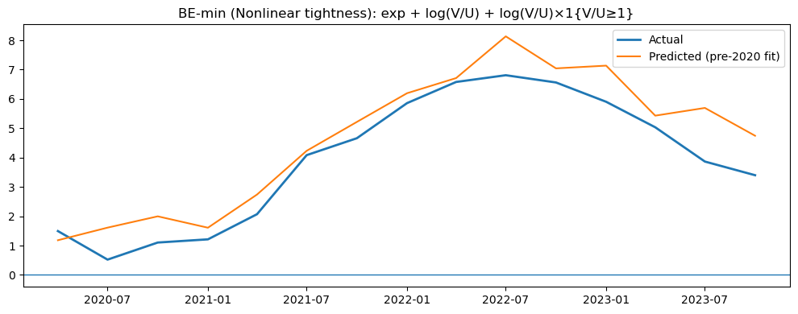

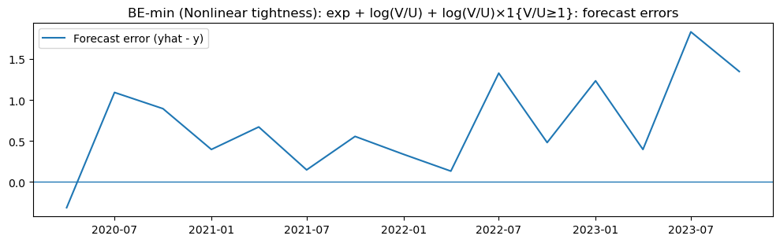

```
BE-min (Nonlinear tightness + energy): exp + log(V/U) + log(V/U)×1{V/U≥1} + energy
Spec: pi_pce_yoy ~ exp_mich_1y_mean + log_vu + log_vu_x_shortage + pi_pce_energy_yoy
Train N=204 | Test N=15 | RMSE=1.066 | MAE=0.898 | Bias=0.868
```

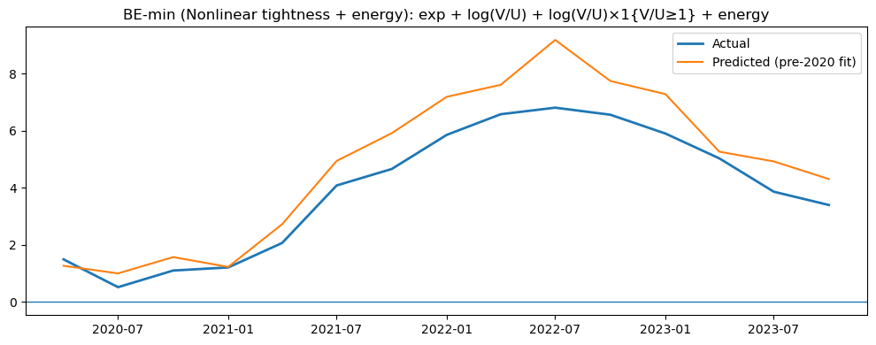

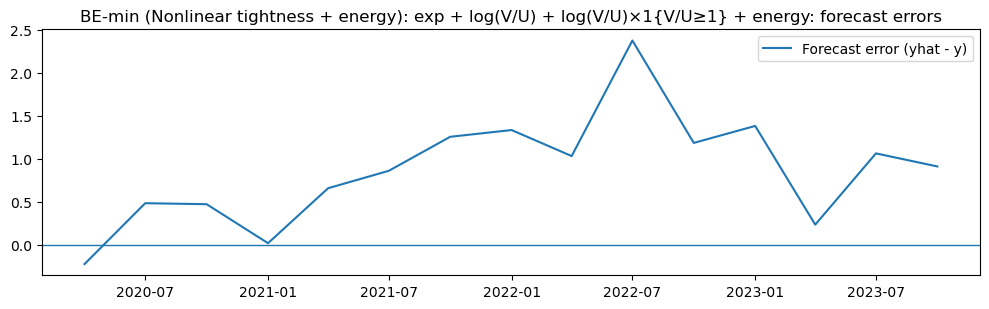

```python
# -----------------------------
# Minimal Benigno–Eggertsson nonlinearity test:
# define "labor shortage" regime as V/U >= 1  <=>  log(V/U) >= 0
# -----------------------------
y = "pi_pce_yoy"
exp = "exp_mich_1y_mean" if "exp_mich_1y_mean" in df_full.columns else "exp_mich_1y_median"

vu_thresh_be = 0.0  # log(V/U) >= 0  <=>  V/U >= 1
print("Benigno–Eggertsson cutoff: log(V/U) >=", vu_thresh_be, " (i.e., V/U >= 1)")

def add_shortage_regime(df, vu_thresh):
    d = df.copy()
    d["shortage"] = (d["log_vu"] >= vu_thresh).astype(float)
    d["log_vu_x_shortage"] = d["log_vu"] * d["shortage"]
    return d

df_train_be = add_shortage_regime(df_train, vu_thresh_be)
df_test_be  = add_shortage_regime(df_test_common, vu_thresh_be)

# BE-A: nonlinear tightness using labor-shortage regime
pc_be_nl = run_and_plot(
    name="BE-min (Nonlinear tightness): exp + log(V/U) + log(V/U)×1{V/U≥1}",
    y=y,
    x=[exp, "log_vu", "log_vu_x_shortage"],
    df_train_use=df_train_be,
    df_test_use=df_test_be
)

# BE-B: same + energy control (since cost-push mattered)
pc_be_nl_energy = run_and_plot(
    name="BE-min (Nonlinear tightness + energy): exp + log(V/U) + log(V/U)×1{V/U≥1} + energy",
    y=y,
    x=[exp, "log_vu", "log_vu_x_shortage", "pi_pce_energy_yoy"],
    df_train_use=df_train_be,
    df_test_use=df_test_be
)
```

### Minimal Benigno–Eggertsson test: labor-shortage regime defined by $V/U \ge 1$

Benigno & Eggertsson’s post-pandemic Phillips curve argument emphasizes a **regime change when the labor market moves into “shortage” territory**, where vacancies exceed unemployed workers. A natural empirical implication is that inflation may respond more strongly to tightness when $V/U$ is high, so the slope of a tightness-based Phillips curve may steepen once $V/U \ge 1$.

To align with this interpretation, we define a labor-shortage indicator using an economically interpretable cutoff: $$ I_t = 1\{V/U \ge 1\} \quad \Leftrightarrow \quad 1\{\log(V/U)\ge 0\}.$$ We then estimate: $$ \pi_t = \alpha + \beta\,\pi_t^e + \kappa_1\,\log(V/U)_t + \kappa_2\,(\log(V/U)_t\cdot I_t) + \varepsilon_t, $$ so that the effective tightness slope in shortage states is $\kappa_1+\kappa_2$. We also consider an augmented version including energy inflation as a cost-push proxy.

**How to read the result.**

- If $\kappa_2>0$ and OOS RMSE falls relative to the linear tightness model, that supports a “steepening in shortage states” interpretation consistent with Benigno–Eggertsson.
- If OOS performance does not improve (or worsens), then the main gains from tightness-based models in this dataset likely come from using $\log(V/U)$ linearly (and from cost-push controls), rather than from a sharp regime change at $V/U=1$.

### Minimal Benigno–Eggertsson nonlinearity test: $V/U \ge 1$ regime does not improve OOS forecasts

To align with Benigno & Eggertsson’s “labor shortage regime” interpretation, we define a high-tightness indicator using the economically interpretable cutoff $V/U \ge 1$ (equivalently, $\log(V/U)\ge 0$) and allow the slope on tightness to change in this regime: $$ \pi_t = \alpha + \beta\,\pi_t^e + \kappa_1\,\log(V/U)_t + \kappa_2\,(\log(V/U)_t\cdot 1\{V/U\ge 1\}) + \varepsilon_t. $$

**Result.**  
This regime-switching specification performs substantially worse than the linear tightness Phillips curve in the post-pandemic OOS window:

- Nonlinear tightness (no energy): RMSE = **0.893**, Bias = **+0.702**
- Nonlinear tightness + energy: RMSE = **1.066**, Bias = **+0.868**

The large positive biases indicate systematic overprediction, and RMSE increases sharply relative to the linear tightness specifications. Thus, within this reduced-form forecasting exercise, the data do not support the view that introducing a sharp kink at $V/U=1$ improves predictive performance. The gains from tightness-based Phillips curves in this dataset appear to come from using $\log(V/U)$ **linearly** (and from including cost-push controls), rather than from a shortage-regime nonlinearity.

### **Slope stability test (post-2020 interaction): does the slack–inflation relationship change?**

```python
# Use full sample up to 2023Q3 (consistent with your test window choice)
df_all = df_full[df_full["period_q"] <= pd.Period("2023Q3", freq="Q")].copy()

def slope_stability_test(df, y, exp_var, slack_var, controls, post_var="post_covid", hac_lags=4, name=""):
    """
    Estimate y ~ exp + slack + controls + slack*post
    Report implied pre and post slack slopes.
    """
    d = df.copy()
    d["slack_post"] = d[slack_var] * d[post_var].astype(float)

    xvars = [exp_var, slack_var, "slack_post"] + list(controls)
    use = d[[y, "period_q"] + xvars].dropna().copy()

    X = sm.add_constant(use[xvars])
    Y = use[y]
    res = sm.OLS(Y, X).fit(cov_type="HAC", cov_kwds={"maxlags": hac_lags})

    kappa_pre = res.params[slack_var]
    delta = res.params["slack_post"]
    kappa_post = kappa_pre + delta

    # SE for post slope = Var(kappa_pre + delta)
    cov = res.cov_params()
    var_post = cov.loc[slack_var, slack_var] + cov.loc["slack_post", "slack_post"] + 2*cov.loc[slack_var, "slack_post"]
    se_post = float(np.sqrt(var_post))

    out = pd.DataFrame({
        "model": [name],
        "N": [len(use)],
        "kappa_pre": [kappa_pre],
        "se_pre": [res.bse[slack_var]],
        "delta_post": [delta],
        "se_delta": [res.bse["slack_post"]],
        "kappa_post": [kappa_post],
        "se_post": [se_post],
        "p_delta": [res.pvalues["slack_post"]],
    })
    return res, out

y = "pi_pce_yoy"
exp = "exp_mich_1y_mean" if "exp_mich_1y_mean" in df_all.columns else "exp_mich_1y_median"

# Spec A: Hazell-style u-gap + energy
res_u_energy, tab_u_energy = slope_stability_test(
    df=df_all,
    y=y,
    exp_var=exp,
    slack_var="u_gap_nroust",
    controls=["pi_pce_energy_yoy"],
    name="Stability: exp + u-gap + energy (+ u-gap×post)"
)

# Spec B: tightness + energy  (best-performing linear tightness spec)
res_vu_energy, tab_vu_energy = slope_stability_test(
    df=df_all,
    y=y,
    exp_var=exp,
    slack_var="log_vu",
    controls=["pi_pce_energy_yoy"],
    name="Stability: exp + log(V/U) + energy (+ log(V/U)×post)"
)

stability_table = pd.concat([tab_u_energy, tab_vu_energy], ignore_index=True)
stability_table
```

|  | model | N | kappa_pre | se_pre | delta_post | se_delta | kappa_post | se_post | p_delta |
| --- | --- | --- | --- | --- | --- | --- | --- | --- | --- |
| 0 | Stability: exp + u-gap + energy (+ u-gap×post) | 219 | 0.037146 | 0.110562 | -0.110566 | 0.112239 | -0.073420 | 0.036922 | 0.324577 |
| 1 | Stability: exp + log(V/U) + energy (+ log(V/U)... | 219 | -0.131704 | 0.302387 | 0.138723 | 0.439434 | 0.007019 | 0.309087 | 0.752241 |

```python
print(res_u_energy.summary())
print(res_vu_energy.summary())
```

```
                            OLS Regression Results
==============================================================================
Dep. Variable:             pi_pce_yoy   R-squared:                       0.843
Model:                            OLS   Adj. R-squared:                  0.840
Method:                 Least Squares   F-statistic:                     135.2
Date:                Sun, 25 Jan 2026   Prob (F-statistic):           2.08e-57
Time:                        13:36:58   Log-Likelihood:                -309.32
No. Observations:                 219   AIC:                             628.6
Df Residuals:                     214   BIC:                             645.6
Df Model:                           4
Covariance Type:                  HAC
=====================================================================================
                        coef    std err          z      P>|z|      [0.025      0.975]
-------------------------------------------------------------------------------------
const                -1.5266      0.327     -4.667      0.000      -2.168      -0.885
exp_mich_1y_mean      1.0218      0.078     13.097      0.000       0.869       1.175
u_gap_nroust          0.0371      0.111      0.336      0.737      -0.180       0.254
slack_post           -0.1106      0.112     -0.985      0.325      -0.331       0.109
pi_pce_energy_yoy     0.0381      0.010      3.992      0.000       0.019       0.057
==============================================================================
Omnibus:                       93.035   Durbin-Watson:                   0.727
Prob(Omnibus):                  0.000   Jarque-Bera (JB):              668.793
Skew:                           1.461   Prob(JB):                    5.93e-146
Kurtosis:                      11.047   Cond. No.                         39.0
==============================================================================

Notes:
[1] Standard Errors are heteroscedasticity and autocorrelation robust (HAC) using 4 lags and without small sample correction
                            OLS Regression Results
==============================================================================
Dep. Variable:             pi_pce_yoy   R-squared:                       0.843
Model:                            OLS   Adj. R-squared:                  0.840
Method:                 Least Squares   F-statistic:                     122.2
Date:                Sun, 25 Jan 2026   Prob (F-statistic):           4.25e-54
Time:                        13:36:58   Log-Likelihood:                -309.51
No. Observations:                 219   AIC:                             629.0
Df Residuals:                     214   BIC:                             646.0
Df Model:                           4
Covariance Type:                  HAC
=====================================================================================
                        coef    std err          z      P>|z|      [0.025      0.975]
-------------------------------------------------------------------------------------
const                -1.6054      0.353     -4.553      0.000      -2.296      -0.914
exp_mich_1y_mean      1.0263      0.079     13.019      0.000       0.872       1.181
log_vu               -0.1317      0.302     -0.436      0.663      -0.724       0.461
slack_post            0.1387      0.439      0.316      0.752      -0.723       1.000
pi_pce_energy_yoy     0.0384      0.009      4.094      0.000       0.020       0.057
==============================================================================
Omnibus:                       92.353   Durbin-Watson:                   0.735
Prob(Omnibus):                  0.000   Jarque-Bera (JB):              665.710
Skew:                           1.447   Prob(JB):                    2.77e-145
Kurtosis:                      11.036   Cond. No.                         94.0
==============================================================================

Notes:
[1] Standard Errors are heteroscedasticity and autocorrelation robust (HAC) using 4 lags and without small sample correction
```

### Capstone test: did the Phillips curve slope change after 2020?

Improved post-pandemic fit can come from adding cost-push proxies (energy/import prices) or using alternative slack measures (tightness), but this does not automatically imply that the **slack–inflation relationship itself** remained stable. To directly test whether the Phillips curve mechanism changed after COVID, we allow the slope on slack to differ post-2020 by interacting slack with a post-pandemic indicator:

$$ \pi_t = \alpha + \beta\,\pi_t^e + \kappa\,slack_t + \delta\,(slack_t \times \mathbf{1}\{t\ge 2020\text{Q1}\}) + \gamma Z_t + \varepsilon_t. $$

Here, $\kappa$ is the pre-2020 slope and $\kappa+\delta$ is the post-2020 slope. We implement this test for two leading specifications motivated by the literature and our forecasting results: (i) unemployment-gap slack with an energy control (Hazell-style), and (ii) tightness slack $\log(V/U)$ with an energy control.

- If $\delta$ is small (and statistically insignificant), this supports the interpretation that the Phillips curve **did not structurally break**; baseline forecast errors primarily reflected omitted shocks/mismeasured slack rather than a changed slope.
- If $\delta$ is large and significant, that indicates a **post-2020 slope shift** even after controlling for energy inflation—consistent with a genuine change in the slack–inflation relationship.

### Capstone result: little evidence of a post-2020 slope break once cost-push is controlled for

To test whether the Phillips curve “broke” in the sense of a changed slack–inflation slope, we augment the preferred specifications with a post-2020 interaction: $$ \pi_t=\alpha+\beta\pi_t^e+\kappa\,slack_t+\delta\,(slack_t\times \mathbf{1}\{t\ge 2020\text{Q1}\})+\gamma\,\pi_t^{energy}+\varepsilon_t, $$ so that $\kappa$ is the pre-2020 slope and $\kappa+\delta$ is the post-2020 slope.

**Result.** In both the unemployment-gap and tightness ($\log(V/U)$) specifications, the post-2020 interaction term is not statistically significant (p-values ≈ 0.33 and 0.75 respectively). Thus, conditional on an energy cost-push proxy and survey expectations, we do not find strong evidence that the Phillips curve slope changed after 2020.

### **Robustness checks for Section 3**

```python
# -----------------------------
# Robustness R1: Cross-era OOS validation
# -----------------------------
# Two evaluation windows:
#   Window A: Train 1968–2007, Test 2008–2019
#   Window B: Train 1968–2019, Test 2020–2023Q3
#
# Uses your existing oos_eval(df_train, df_test, y, x, hac_lags=4)

def make_window(df, start_q, end_q):
    return df[(df["period_q"] >= pd.Period(start_q, freq="Q")) &
              (df["period_q"] <= pd.Period(end_q, freq="Q"))].copy()

# Define windows (consistent with your earlier Section 2 window logic)
train_A = make_window(df_full, "1968Q1", "2007Q4")
test_A  = make_window(df_full, "2008Q1", "2019Q4")

train_B = make_window(df_full, "1968Q1", "2019Q4")
test_B  = make_window(df_full, "2020Q1", "2023Q3")

# Preferred expectations proxy
exp = "exp_mich_1y_mean" if "exp_mich_1y_mean" in df_full.columns else "exp_mich_1y_median"

# Define the three Section 3 specs you want to validate
specs = [
    ("PC u-gap + energy (Hazell)", [exp, "u_gap_nroust", "pi_pce_energy_yoy"]),
    ("PC u-gap + import (bottlenecks)", [exp, "u_gap_nroust", "import_def_yoy"]),
    ("PC log(V/U) + energy (tightness)", [exp, "log_vu", "pi_pce_energy_yoy"]),
]

def eval_specs_in_window(y, train_df, test_df, window_label, specs, hac_lags=4):
    rows = []
    for name, x in specs:
        out = oos_eval(train_df, test_df, y, x, hac_lags=hac_lags)
        m = out["metrics"]
        rows.append({
            "window": window_label,
            "y": y,
            "spec": name,
            "train_N": m["train_N"],
            "test_N": m["test_N"],
            "RMSE": m["rmse"],
            "MAE": m["mae"],
            "Bias": m["bias"],
        })
    return pd.DataFrame(rows)

y_target = "pi_pce_yoy"

r1_A = eval_specs_in_window(y_target, train_A, test_A, "Train 1968–2007, Test 2008–2019", specs)
r1_B = eval_specs_in_window(y_target, train_B, test_B, "Train 1968–2019, Test 2020–2023Q3", specs)

r1_table = pd.concat([r1_A, r1_B], ignore_index=True)
r1_table.sort_values(["window", "RMSE"])
```

|  | window | y | spec | train_N | test_N | RMSE | MAE | Bias |
| --- | --- | --- | --- | --- | --- | --- | --- | --- |
| 2 | Train 1968–2007, Test 2008–2019 | pi_pce_yoy | PC log(V/U) + energy (tightness) | 156 | 48 | 1.574350 | 1.270801 | 1.222823 |
| 0 | Train 1968–2007, Test 2008–2019 | pi_pce_yoy | PC u-gap + energy (Hazell) | 156 | 48 | 1.621781 | 1.357406 | 1.356819 |
| 1 | Train 1968–2007, Test 2008–2019 | pi_pce_yoy | PC u-gap + import (bottlenecks) | 156 | 48 | 1.789675 | 1.488528 | 1.487857 |
| 5 | Train 1968–2019, Test 2020–2023Q3 | pi_pce_yoy | PC log(V/U) + energy (tightness) | 204 | 15 | 0.562787 | 0.455831 | 0.305249 |
| 3 | Train 1968–2019, Test 2020–2023Q3 | pi_pce_yoy | PC u-gap + energy (Hazell) | 204 | 15 | 0.617802 | 0.509203 | 0.373498 |
| 4 | Train 1968–2019, Test 2020–2023Q3 | pi_pce_yoy | PC u-gap + import (bottlenecks) | 204 | 15 | 0.708073 | 0.591115 | 0.111105 |

### Robustness R1: cross-era validation (motivated by window sensitivity in Section 2)

Section 2 showed that inflation forecasting performance is strongly evaluation-window dependent: the post-pandemic period is unusually difficult to forecast even for simple benchmarks. To ensure that the Section 3 “rescued Phillips curve” specifications are not merely COVID-specific patches, we re-evaluate our three leading Phillips-curve variants in an earlier out-of-sample window.

We compare OOS performance in two windows:

1. **Train 1968–2007, test 2008–2019** (post-GFC low-inflation era)
2. **Train 1968–2019, test 2020–2023Q3** (post-pandemic inflation era)

Each specification uses the same expectations proxy and differs only in the slack proxy and/or the cost-push control (energy vs import prices). If the augmented specifications improve fit in both windows (or at least do not deteriorate in the earlier window), that supports the interpretation that they reflect a more robust NKPC-style specification rather than an episode-specific adjustment.

### Robustness R1 result: cross-era validation highlights strong regime dependence

Re-estimating and evaluating the leading Section 3 Phillips-curve variants across two OOS windows reveals pronounced **regime dependence**.

In the post-pandemic window (2020Q1–2023Q3), the augmented specifications perform well (e.g., tightness+energy RMSE ≈ 0.56; u-gap+energy RMSE ≈ 0.62; u-gap+import RMSE ≈ 0.71), consistent with the view that incorporating cost-push proxies and/or tighter slack measures can explain much of the baseline “failure to predict.”

However, when evaluated in the post-GFC low-inflation era (2008–2019), the same specifications perform poorly and exhibit large **positive biases** (≈ +1.2 to +1.5pp), implying systematic overprediction of inflation. This suggests that these Phillips-curve variants capture the post-pandemic inflation regime but do not generalize to the earlier anchored-inflation regime without further modeling of trend inflation/expectations anchoring or additional mechanisms.

**Interpretation.**  
Combined with Section 2’s window-sensitivity evidence, this cross-era exercise implies that pseudo-OOS “success” in 2020–2023 should not be interpreted as identifying a universally stable Phillips curve. Instead, the evidence points to instability across monetary/inflation regimes: post-pandemic inflation dynamics are better matched by specifications with cost-push proxies and tightness measures, whereas the post-GFC era remains difficult to reconcile in the same reduced-form framework.

```python
# -----------------------------
# R1b: Cross-era validation using SPF 1-year expectations instead of Michigan
# -----------------------------
import pandas as pd

def make_window(df, start_q, end_q):
    return df[(df["period_q"] >= pd.Period(start_q, freq="Q")) &
              (df["period_q"] <= pd.Period(end_q, freq="Q"))].copy()

train_A = make_window(df_full, "1968Q1", "2007Q4")
test_A  = make_window(df_full, "2008Q1", "2019Q4")

train_B = make_window(df_full, "1968Q1", "2019Q4")
test_B  = make_window(df_full, "2020Q1", "2023Q3")

# Use SPF 1-year expectations (must exist)
exp_spf = "exp_spf_1y"
assert exp_spf in df_full.columns, "exp_spf_1y not found. Check transforms/column names."

specs_spf = [
    ("PC u-gap + energy (Hazell) [SPF1y]", [exp_spf, "u_gap_nroust", "pi_pce_energy_yoy"]),
    ("PC u-gap + import (bottlenecks) [SPF1y]", [exp_spf, "u_gap_nroust", "import_def_yoy"]),
    ("PC log(V/U) + energy (tightness) [SPF1y]", [exp_spf, "log_vu", "pi_pce_energy_yoy"]),
]

def eval_specs_in_window(y, train_df, test_df, window_label, specs, hac_lags=4):
    rows = []
    for name, x in specs:
        out = oos_eval(train_df, test_df, y, x, hac_lags=hac_lags)
        m = out["metrics"]
        rows.append({
            "window": window_label,
            "y": y,
            "spec": name,
            "train_N": m["train_N"],
            "test_N": m["test_N"],
            "RMSE": m["rmse"],
            "MAE": m["mae"],
            "Bias": m["bias"],
        })
    return pd.DataFrame(rows)

y_target = "pi_pce_yoy"

r1b_A = eval_specs_in_window(y_target, train_A, test_A, "Train 1968–2007, Test 2008–2019", specs_spf)
r1b_B = eval_specs_in_window(y_target, train_B, test_B, "Train 1968–2019, Test 2020–2023Q3", specs_spf)

r1b_table_spf = pd.concat([r1b_A, r1b_B], ignore_index=True)

# Display sorted within window
r1b_table_spf.sort_values(["window", "RMSE"])
```

|  | window | y | spec | train_N | test_N | RMSE | MAE | Bias |
| --- | --- | --- | --- | --- | --- | --- | --- | --- |
| 0 | Train 1968–2007, Test 2008–2019 | pi_pce_yoy | PC u-gap + energy (Hazell) [SPF1y] | 106 | 48 | 0.304998 | 0.234575 | -0.007524 |
| 2 | Train 1968–2007, Test 2008–2019 | pi_pce_yoy | PC log(V/U) + energy (tightness) [SPF1y] | 106 | 48 | 0.356723 | 0.287739 | -0.072168 |
| 1 | Train 1968–2007, Test 2008–2019 | pi_pce_yoy | PC u-gap + import (bottlenecks) [SPF1y] | 106 | 48 | 0.372729 | 0.281537 | 0.158088 |
| 3 | Train 1968–2019, Test 2020–2023Q3 | pi_pce_yoy | PC u-gap + energy (Hazell) [SPF1y] | 154 | 15 | 1.746672 | 1.441684 | -1.420438 |
| 5 | Train 1968–2019, Test 2020–2023Q3 | pi_pce_yoy | PC log(V/U) + energy (tightness) [SPF1y] | 154 | 15 | 1.904800 | 1.619557 | -1.619557 |
| 4 | Train 1968–2019, Test 2020–2023Q3 | pi_pce_yoy | PC u-gap + import (bottlenecks) [SPF1y] | 154 | 15 | 2.071303 | 1.731859 | -1.577464 |

### Robustness (expectations proxy): SPF expectations flip the cross-era results

Repeating the cross-era OOS validation using **SPF 1-year expectations** (instead of Michigan) yields a striking reversal.

In the post-GFC low-inflation era (2008–2019), Phillips-curve variants with SPF expectations perform extremely well (RMSE ≈ 0.30–0.37) and exhibit little bias. This suggests that professional expectations were well aligned with realized inflation in the anchored regime, and that earlier overprediction using Michigan expectations reflected a mismatch between household expectations and realized inflation in this period.

However, in the post-pandemic window (2020–2023Q3), the SPF-based specifications perform very poorly (RMSE ≈ 1.75–2.07) with large negative biases (≈ −1.4 to −1.6pp), implying systematic underprediction of the inflation surge. In contrast, the Michigan-based specifications fit the post-pandemic window far better.

**Interpretation.**  
These results imply that conclusions about “Phillips curve failure” are highly sensitive to the measurement of expected inflation. Professional expectations appear better suited to the low-inflation/anchored regime, while household expectations better capture the re-anchoring/unanchoring dynamics of the post-pandemic episode. This motivates treating expectations measurement as a central identification issue rather than a minor robustness choice.

```python
# -----------------------------
# Robustness R2: swap supply proxy (energy vs oil vs gasoline)
# -----------------------------
y = "pi_pce_yoy"
exp = "exp_mich_1y_mean" if "exp_mich_1y_mean" in df_full.columns else "exp_mich_1y_median"
slack = "log_vu"

# OOS window: train pre-2020, test 2020–2023Q3 (your main COVID window)
df_train_R2 = df_train
df_test_R2  = df_test_common

supply_proxies = [
    ("PCE energy inflation", "pi_pce_energy_yoy"),
    ("Brent oil inflation", "oil_yoy"),
    ("Gas price inflation", "gas_price_yoy"),
]

rows = []
outs = {}

for label, z in supply_proxies:
    name = f"R2: exp + {slack} + {label}"
    out = oos_eval(df_train_R2, df_test_R2, y, [exp, slack, z], hac_lags=4)
    m = out["metrics"]
    rows.append({
        "supply_proxy": label,
        "z_var": z,
        "train_N": m["train_N"],
        "test_N": m["test_N"],
        "RMSE": m["rmse"],
        "MAE": m["mae"],
        "Bias": m["bias"],
    })
    outs[label] = out

r2_table = pd.DataFrame(rows).sort_values("RMSE")
r2_table
```

|  | supply_proxy | z_var | train_N | test_N | RMSE | MAE | Bias |
| --- | --- | --- | --- | --- | --- | --- | --- |
| 0 | PCE energy inflation | pi_pce_energy_yoy | 204 | 15 | 0.562787 | 0.455831 | 0.305249 |
| 1 | Brent oil inflation | oil_yoy | 180 | 15 | 0.631994 | 0.543500 | 0.061613 |
| 2 | Gas price inflation | gas_price_yoy | 108 | 15 | 1.341489 | 1.026187 | -0.970238 |

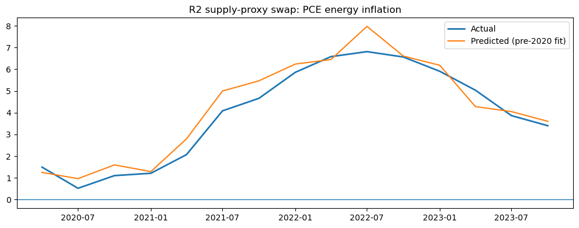

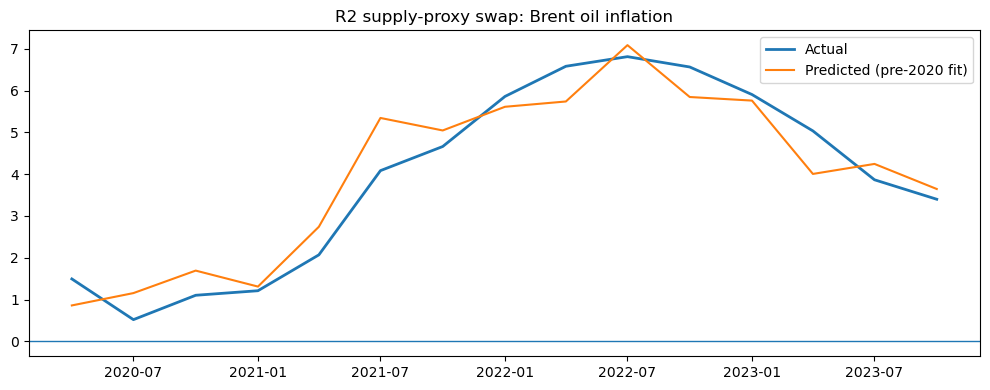

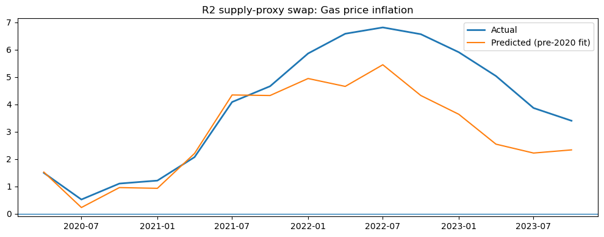

```python
import matplotlib.pyplot as plt

for label, out in outs.items():
    d = out["dtest"].copy()
    plt.figure(figsize=(10,4))
    plt.plot(d["date"], d[y], label="Actual", linewidth=2)
    plt.plot(d["date"], d["yhat"], label="Predicted (pre-2020 fit)")
    plt.axhline(0, linewidth=1)
    plt.title(f"R2 supply-proxy swap: {label}")
    plt.legend()
    plt.tight_layout()
    plt.show()
```

### Robustness R2: does the “supply control rescues fit” result depend on the specific proxy?

To check that our Section 3 conclusions are not driven by a single energy measure, we re-estimate the same Phillips-curve specification while swapping alternative supply/cost proxies available in the dataset:

- PCE energy inflation (direct energy component of the price index),
- Brent oil inflation (global crude price proxy),
- gasoline price inflation (consumer-facing energy price proxy).

We hold fixed the expectations proxy and slack measure, and evaluate each variant out-of-sample over 2020Q1–2023Q3. If results are robust across these proxies, it strengthens the interpretation that the post-pandemic forecast errors reflect an omitted **cost-push/supply-shock** component rather than an idiosyncratic measurement choice.

```python
# -----------------------------
# Robustness R3: use core inflation target (core PCE)
# -----------------------------
y_core = "pi_corepce_yoy"
exp = "exp_mich_1y_mean" if "exp_mich_1y_mean" in df_full.columns else "exp_mich_1y_median"
slack = "log_vu"

# Ensure core target exists
assert y_core in df_full.columns, "pi_corepce_yoy not found. Check transforms / column names."

# Compare a small ladder of specs on the core target
specs_core = [
    ("Core PC: exp + log(V/U)", [exp, slack]),
    ("Core PC: exp + log(V/U) + energy", [exp, slack, "pi_pce_energy_yoy"]),
    ("Core PC: exp + log(V/U) + import", [exp, slack, "import_def_yoy"]),
    ("Core PC: exp + log(V/U) + oil", [exp, slack, "oil_yoy"]),
]

rows = []
outs_core = {}

for name, x in specs_core:
    out = oos_eval(df_train, df_test_common, y_core, x, hac_lags=4)
    m = out["metrics"]
    rows.append({
        "model": name,
        "train_N": m["train_N"],
        "test_N": m["test_N"],
        "RMSE": m["rmse"],
        "MAE": m["mae"],
        "Bias": m["bias"],
    })
    outs_core[name] = out

r3_core_table = pd.DataFrame(rows).sort_values("RMSE")
r3_core_table
```

|  | model | train_N | test_N | RMSE | MAE | Bias |
| --- | --- | --- | --- | --- | --- | --- |
| 2 | Core PC: exp + log(V/U) + import | 204 | 15 | 0.592885 | 0.485386 | 0.192858 |
| 0 | Core PC: exp + log(V/U) | 204 | 15 | 0.596508 | 0.495105 | 0.160161 |
| 1 | Core PC: exp + log(V/U) + energy | 204 | 15 | 0.651971 | 0.504852 | 0.131050 |
| 3 | Core PC: exp + log(V/U) + oil | 180 | 15 | 0.670309 | 0.560059 | 0.035703 |

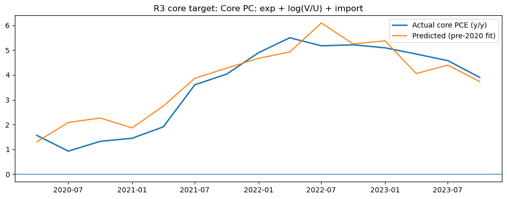

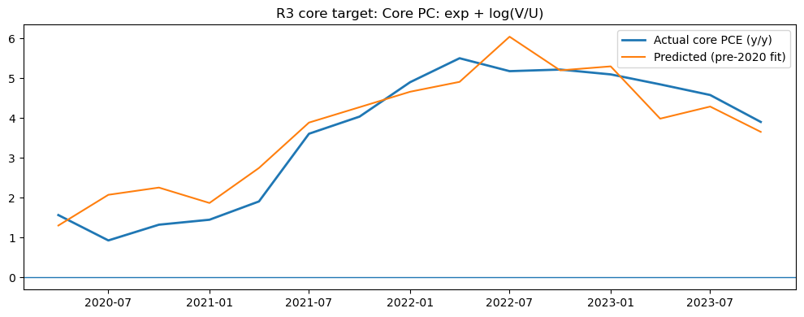

```python
# pick the best 2 rows by RMSE
best_models = r3_core_table["model"].head(2).tolist()

for mname in best_models:
    d = outs_core[mname]["dtest"].copy()
    plt.figure(figsize=(10,4))
    plt.plot(d["date"], d[y_core], label="Actual core PCE (y/y)", linewidth=2)
    plt.plot(d["date"], d["yhat"], label="Predicted (pre-2020 fit)")
    plt.axhline(0, linewidth=1)
    plt.title(f"R3 core target: {mname}")
    plt.legend()
    plt.tight_layout()
    plt.show()
```

### Robustness R3 result: core inflation behaves differently (import matters more than energy)

Repeating the key tightness-based Phillips-curve specifications using **core PCE inflation** yields a clear contrast with the headline results. The linear tightness Phillips curve performs well for core inflation (RMSE ≈ **0.60**), and adding **import-price inflation** slightly improves fit further (RMSE ≈ **0.59**). In contrast, adding **energy inflation** does not improve performance for core inflation (RMSE rises to ≈ **0.65**), consistent with the fact that core PCE excludes direct energy components.

**Interpretation.**  
This strengthens the Section 3 conclusion by showing that improvements from supply proxies are not purely mechanical: energy controls primarily help explain headline inflation dynamics, whereas import-price inflation provides the more relevant supply-side proxy for core inflation (consistent with broader bottleneck/traded-goods cost channels).

For core PCE, adding energy inflation does not improve OOS performance, while adding import-price inflation yields at most a modest improvement. The main predictive content for core inflation comes from expectations and the tightness measure itself, consistent with the idea that energy controls primarily matter for headline inflation.

### Section 3 conclusion: Phillips curve variants, nonlinearity, stability, and robustness

This section evaluated whether the apparent post-pandemic “Phillips curve failure” reflects (i) misspecification/omitted shocks, (ii) slack mismeasurement, or (iii) a structural change in the slack–inflation relationship. We estimate each specification on the pre-2020 sample and evaluate out-of-sample (OOS) forecasts over 2020Q1–2023Q3, motivated by post-pandemic Phillips curve debates.

**3) Nonlinearity (kinked/slanted-L) specifications do not improve forecasting performance here.**  
Motivated by “steepening in very tight labor markets” arguments, we tested threshold nonlinearity using (i) a training-sample high-tightness cutoff and (ii) an economically interpretable labor-shortage regime cutoff $V/U\ge 1$ (Benigno–Eggertsson style). In both cases, the nonlinear interaction specifications worsen OOS performance and introduce large positive biases. In this quarterly dataset and forecasting design, the evidence favors linear tightness specifications over kinked regime-switching forms.

**4) Capstone stability check: no clear evidence of a post-2020 slope break once cost-push is controlled for.**  
Allowing the slack coefficient to differ post-2020 via a $slack \times post$ interaction yields no statistically significant slope shift in either the unemployment-gap or tightness-based specification (conditional on energy inflation and survey expectations). This supports the view that the post-pandemic “failure” is primarily about omitted shocks and slack/expectations measurement rather than a clear structural collapse of the slack–inflation slope (noting that estimates are imprecise and the post-2020 window is short).

**5) Robustness: regime dependence and expectations measurement are central.**  
A cross-era OOS validation shows that the post-pandemic “best” specifications do not automatically generalize to 2008–2019 when household expectations are used (large overprediction), while using SPF 1-year expectations produces excellent performance in 2008–2019 but large underprediction in 2020–2023Q3. This highlights that conclusions about Phillips curve “failure” are highly sensitive to how expected inflation is measured and that expectation formation appears regime-dependent.

**6) Robustness: alternative supply proxies and core inflation.**  
Swapping supply proxies shows that headline results are robust to using Brent oil inflation as a cost-push proxy (with somewhat weaker accuracy but much smaller bias), while gasoline inflation performs poorly largely due to limited/noisy sample coverage. Using core PCE inflation as the target, energy inflation no longer improves fit (consistent with “not just energy explains energy”), while import-price inflation provides at most a modest improvement; for core inflation, most predictive content comes from expectations and tightness rather than energy.

```python
import matplotlib.pyplot as plt
import pandas as pd
import numpy as np

# -----------------------------
# Exhibit 3: Table of Phillips curve variants (OOS 2020Q1–2023Q3)
# Metrics: RMSE / MAE / Bias
# Plus slack slope: kappa (HAC s.e.) and standardized kappa * sd(slack)
# Note: df_full, df_train, df_test_common, and oos_eval should be defined in earlier cells
# -----------------------------

y = "pi_pce_yoy"
exp = "exp_mich_1y_mean" if "exp_mich_1y_mean" in df_full.columns else "exp_mich_1y_median"

# Ensure we have a baseline *consistent with Section 3* (Michigan mean if available)
pc_base_mean = oos_eval(df_train, df_test_common, y, [exp, "u_gap_nroust"], hac_lags=4)

def extract_row(name, out, slack_var):
    m = out["metrics"]
    res = out["res"]
    dtr = out["dtrain"]

    kappa = float(res.params.get(slack_var, np.nan))
    se_kappa = float(res.bse.get(slack_var, np.nan))
    sd_slack = float(dtr[slack_var].std(ddof=1)) if slack_var in dtr.columns else np.nan
    kappa_std = kappa * sd_slack if np.isfinite(kappa) and np.isfinite(sd_slack) else np.nan

    return {
        "Model": name,
        "Slack": slack_var,
        "Train N": m["train_N"],
        "Test N": m["test_N"],
        "RMSE": m["rmse"],
        "MAE": m["mae"],
        "Bias": m["bias"],
        "kappa": kappa,
        "SE(kappa)": se_kappa,
        "kappa × sd(slack)": kappa_std,
    }

# Build the model list from objects you already created in Section 3
models = [
    ("Baseline: exp + u-gap", pc_base_mean, "u_gap_nroust"),
    ("V1 Hazell: + energy", pc_energy, "u_gap_nroust"),
    ("V2A Bottlenecks: + import", pc_import, "u_gap_nroust"),
    # include if you want; otherwise comment out
    ("V2B: + import + oil", pc_import_oil, "u_gap_nroust"),
    ("V3A Tightness: log(V/U)", pc_vu, "log_vu"),
    ("V3B Tightness + energy", pc_vu_energy, "log_vu"),
    ("V3C Tightness + import", pc_vu_import, "log_vu"),
]

rows = [extract_row(n, out, slack) for n, out, slack in models]
tab3 = pd.DataFrame(rows)

# Format for display
tab3_disp = tab3.copy()
for c in ["RMSE","MAE","Bias","kappa","SE(kappa)","kappa × sd(slack)"]:
    tab3_disp[c] = tab3_disp[c].map(lambda v: np.nan if pd.isna(v) else float(v))
tab3_disp = tab3_disp.sort_values("RMSE").reset_index(drop=True)

# Round
tab3_disp_rounded = tab3_disp.copy()
tab3_disp_rounded[["RMSE","MAE","Bias","kappa","SE(kappa)","kappa × sd(slack)"]] = \
    tab3_disp_rounded[["RMSE","MAE","Bias","kappa","SE(kappa)","kappa × sd(slack)"]].round(3)

tab3_disp_rounded
```

|  | Model | Slack | Train N | Test N | RMSE | MAE | Bias | kappa | SE(kappa) | kappa × sd(slack) |
| --- | --- | --- | --- | --- | --- | --- | --- | --- | --- | --- |
| 0 | V3B Tightness + energy | log_vu | 204 | 15 | 0.563 | 0.456 | 0.305 | -0.082 | 0.316 | -0.038 |
| 1 | V1 Hazell: + energy | u_gap_nroust | 204 | 15 | 0.618 | 0.509 | 0.373 | 0.035 | 0.111 | 0.050 |
| 2 | V3C Tightness + import | log_vu | 204 | 15 | 0.625 | 0.530 | -0.031 | -0.183 | 0.343 | -0.084 |
| 3 | Baseline: exp + u-gap | u_gap_nroust | 204 | 15 | 0.633 | 0.564 | 0.267 | -0.002 | 0.105 | -0.003 |
| 4 | V3A Tightness: log(V/U) | log_vu | 204 | 15 | 0.636 | 0.566 | 0.238 | -0.041 | 0.318 | -0.019 |
| 5 | V2A Bottlenecks: + import | u_gap_nroust | 204 | 15 | 0.708 | 0.591 | 0.111 | 0.080 | 0.126 | 0.114 |
| 6 | V2B: + import + oil | u_gap_nroust | 180 | 15 | 0.759 | 0.620 | 0.101 | 0.123 | 0.138 | 0.168 |

```python
import numpy as np
import pandas as pd

# ---- choose your baseline expectations proxy
y = "pi_pce_yoy"
exp = "exp_mich_1y_mean" if "exp_mich_1y_mean" in df_full.columns else "exp_mich_1y_median"

# ensure a consistent baseline object (recompute once)
pc_base = oos_eval(df_train, df_test_common, y, [exp, "u_gap_nroust"], hac_lags=4)

# ---- helper formatters
def fmt(x, nd=3):
    return "" if pd.isna(x) else f"{float(x):.{nd}f}"

def coef_se(res, var, nd=3):
    if var not in res.params:
        return "", ""
    return fmt(res.params[var], nd), f"({fmt(res.bse[var], nd)})"

def build_col(out, slack_var):
    m = out["metrics"]
    res = out["res"]
    b, se = coef_se(res, slack_var, 3)
    return {
        "coef": b,
        "se": se,
        "RMSE": fmt(m["rmse"], 3),
        "Bias": fmt(m["bias"], 3),
        "Train N": str(int(m["train_N"])),
        "Test N": str(int(m["test_N"])),
    }

models = [
    # Panel A: unemployment gap specs
    ("Baseline\n(exp + u-gap)",      pc_base,        "u_gap_nroust", "A"),
    ("+ Energy\n(Hazell)",           pc_energy,      "u_gap_nroust", "A"),
    ("+ Import\n(bottlenecks)",      pc_import,      "u_gap_nroust", "A"),
    # ("+ Import + Oil",             pc_import_oil,  "u_gap_nroust", "A"),

    # Panel B: tightness specs
    ("Tightness\n(exp + log V/U)",   pc_vu,          "log_vu",       "B"),
    ("Tightness\n+ Energy",          pc_vu_energy,   "log_vu",       "B"),
    ("Tightness\n+ Import",          pc_vu_import,   "log_vu",       "B"),
]

# ---- build column blocks
cols_A = [(name, out, slack) for name, out, slack, panel in models if panel == "A"]
cols_B = [(name, out, slack) for name, out, slack, panel in models if panel == "B"]

def make_block(cols, block_title):
    """
    Returns a DataFrame formatted as:
      row1: Slack slope
      row2: (SE)
      then RMSE, Bias, Train N, Test N
    """
    data = {}
    for name, out, slack_var in cols:
        data[name] = build_col(out, slack_var)

    # row order
    rows = [
        ("Slack slope", "coef"),
        ("", "se"),
        ("RMSE", "RMSE"),
        ("Bias", "Bias"),
        ("Train N", "Train N"),
        ("Test N", "Test N"),
    ]

    block = pd.DataFrame(
        {col: [data[col][key] for _, key in rows] for col in data.keys()},
        index=[r for r, _ in rows]
    )

    # Add a panel header row (will be inserted later in LaTeX)
    return block, block_title

blockA, titleA = make_block(cols_A, "Panel A: Unemployment-gap Phillips curves")
blockB, titleB = make_block(cols_B, "Panel B: Tightness Phillips curves (log V/U)")

# ---- combine blocks with blank line between (for readability in notebook)
combined = pd.concat([blockA, pd.DataFrame([[""]*blockA.shape[1]], columns=blockA.columns, index=[""]), blockB])
combined
```

|  | Baseline\n(exp + u-gap) | + Energy\n(Hazell) | + Import\n(bottlenecks) | Tightness\n(exp + log V/U) | Tightness\n+ Energy | Tightness\n+ Import |
| --- | --- | --- | --- | --- | --- | --- |
| Slack slope | -0.002 | 0.035 | 0.080 | NaN | NaN | NaN |
|  | (0.105) | (0.111) | (0.126) | NaN | NaN | NaN |
| RMSE | 0.633 | 0.618 | 0.708 | NaN | NaN | NaN |
| Bias | 0.267 | 0.373 | 0.111 | NaN | NaN | NaN |
| Train N | 204 | 204 | 204 | NaN | NaN | NaN |
| Test N | 15 | 15 | 15 | NaN | NaN | NaN |
|  |  |  |  | NaN | NaN | NaN |
| Slack slope | NaN | NaN | NaN | -0.041 | -0.082 | -0.183 |
|  | NaN | NaN | NaN | (0.318) | (0.316) | (0.343) |
| RMSE | NaN | NaN | NaN | 0.636 | 0.563 | 0.625 |
| Bias | NaN | NaN | NaN | 0.238 | 0.305 | -0.031 |
| Train N | NaN | NaN | NaN | 204 | 204 | 204 |
| Test N | NaN | NaN | NaN | 15 | 15 | 15 |

#### **Figure 3/Table 1 used in paper**

```python
# Writing a latex table file
tex_path = "../results/exhibit3_pc_variants.tex"

def block_to_latex(blockA, titleA, blockB, titleB, caption, label):
    # Convert blocks to LaTeX tabular with booktabs
    cols = list(blockA.columns) if blockA.shape[1] > 0 else list(blockB.columns)
    col_fmt = "l" + "c"*len(cols)

    def df_tabular(df):
        return df.to_latex(
            escape=False,
            index=True,
            header=True,
            column_format=col_fmt,
            bold_rows=False
        )

    # We’ll manually insert panel titles using \multicolumn
    latexA = df_tabular(blockA)
    latexB = df_tabular(blockB)

    # Strip the default \begin{tabular}...\end{tabular} wrappers so we can stitch panels cleanly
    def strip_tabular(lx):
        lines = lx.splitlines()
        lines = [ln for ln in lines if not ln.startswith("\\begin{tabular}") and not ln.startswith("\\end{tabular}")]
        return "\n".join(lines)

    bodyA = strip_tabular(latexA)
    bodyB = strip_tabular(latexB)

    # Build full table
    out = []
    out.append("\\begin{table}[!htbp]")
    out.append("\\centering")
    out.append(f"\\caption{{{caption}}}")
    out.append(f"\\label{{{label}}}")
    out.append("\\small")
    out.append(f"\\begin{{tabular}}{{{col_fmt}}}")
    out.append("\\toprule")
    out.append(" & " + " & ".join(cols) + " \\\\")
    out.append("\\midrule")
    out.append(f"\\multicolumn{{{len(cols)+1}}}{{l}}{{\\textit{{{titleA}}}}} \\\\")
    out.append("\\midrule")
    out.append(bodyA)
    out.append("\\midrule")
    out.append(f"\\multicolumn{{{len(cols)+1}}}{{l}}{{\\textit{{{titleB}}}}} \\\\")
    out.append("\\midrule")
    out.append(bodyB)
    out.append("\\bottomrule")
    out.append("\\end{tabular}")
    out.append("\\end{table}")
    return "\n".join(out)

latex_table = block_to_latex(
    blockA, titleA, blockB, titleB,
    caption="Exhibit 3: Phillips curve variants (OOS 2020Q1--2023Q3)",
    label="tab:pc_variants"
)

with open(tex_path, "w") as f:
    f.write(latex_table)

print("Wrote LaTeX table to:", tex_path)
print("\n--- Preview (first ~40 lines) ---\n")
print("\n".join(latex_table.splitlines()[:40]))
```

```
Wrote LaTeX table to: ../results/exhibit3_pc_variants.tex

--- Preview (first ~40 lines) ---

\begin{table}[!htbp]
\centering
\caption{Exhibit 3: Phillips curve variants (OOS 2020Q1--2023Q3)}
\label{tab:pc_variants}
\small
\begin{tabular}{lccc}
\toprule
 & Baseline
(exp + u-gap) & + Energy
(Hazell) & + Import
(bottlenecks) \\
\midrule
\multicolumn{4}{l}{\textit{Panel A: Unemployment-gap Phillips curves}} \\
\midrule
\toprule
 & Baseline
(exp + u-gap) & + Energy
(Hazell) & + Import
(bottlenecks) \\
\midrule
Slack slope & -0.002 & 0.035 & 0.080 \\
 & (0.105) & (0.111) & (0.126) \\
RMSE & 0.633 & 0.618 & 0.708 \\
Bias & 0.267 & 0.373 & 0.111 \\
Train N & 204 & 204 & 204 \\
Test N & 15 & 15 & 15 \\
\bottomrule
\midrule
\multicolumn{4}{l}{\textit{Panel B: Tightness Phillips curves (log V/U)}} \\
\midrule
\toprule
 & Tightness
(exp + log V/U) & Tightness
+ Energy & Tightness
+ Import \\
\midrule
Slack slope & -0.041 & -0.082 & -0.183 \\
 & (0.318) & (0.316) & (0.343) \\
RMSE & 0.636 & 0.563 & 0.625 \\
Bias & 0.238 & 0.305 & -0.031 \\
```

#### **Figure 4/Table 2 used in paper**

```python
import os
import numpy as np
import pandas as pd

# -----------------------------
# Exhibit 4 (reproducible): Regime dependence + inflation target robustness
# Inputs already in notebook:
#   r1_table (Michigan cross-era)
#   r1b_table_spf (SPF cross-era)
#   r3_core_table (core target)
# -----------------------------

assert "r1_table" in globals(), "r1_table not found."
assert "r1b_table_spf" in globals(), "r1b_table_spf not found."
assert "r3_core_table" in globals(), "r3_core_table not found."

def fmt(x, nd=3):
    return f"{float(x):.{nd}f}" if pd.notna(x) else ""

def pick_row(df, window_contains, spec_contains):
    """Pick a single row by partial match on window and spec."""
    m = df["window"].astype(str).str.contains(window_contains, regex=False)
    s = df["spec"].astype(str).str.contains(spec_contains, regex=False)
    sub = df[m & s].copy()
    if len(sub) == 0:
        raise ValueError(f"No match for window_contains='{window_contains}', spec_contains='{spec_contains}'.")
    if len(sub) > 1:
        # choose the first deterministically (can tighten if needed)
        sub = sub.iloc[[0]]
    return sub.iloc[0]

# ---- choose the ONE model we use for the regime-dependence panel
# This matches your Section 3 "best" headline spec:
#   PC log(V/U) + energy (tightness)
SPEC_MICH = "PC log(V/U) + energy"          # in r1_table
SPEC_SPF  = "PC log(V/U) + energy"          # in r1b_table_spf (it has suffix [SPF1y], but substring matches)

# Windows used in your tables
WIN_08019 = "Test 2008–2019"
WIN_2023  = "Test 2020–2023Q3"

# Pull regime-dependence metrics
m_08019 = pick_row(r1_table,  "2008–2019", SPEC_MICH)
m_2023  = pick_row(r1_table,  "2020–2023Q3", SPEC_MICH)

s_08019 = pick_row(r1b_table_spf, "2008–2019", SPEC_SPF)
s_2023  = pick_row(r1b_table_spf, "2020–2023Q3", SPEC_SPF)

# Pull core-target metrics (these are already for the COVID OOS window)
# We use:
#  - Core PC: exp + log(V/U) + energy
#  - Core PC: exp + log(V/U) + import
core_energy = r3_core_table[r3_core_table["model"].str.contains(r"log\(V/U\) \+ energy", regex=True)].iloc[0]
core_import = r3_core_table[r3_core_table["model"].str.contains(r"log\(V/U\) \+ import", regex=True)].iloc[0]

# Headline reference for Panel B: use Michigan tightness+energy in 2020–2023Q3 from cross-era table
headline_ref = m_2023

# Build LaTeX table body rows
rows_panelA = [
    (r"\makecell[l]{Test 2008--2019 (train 1968--2007)\\Michigan mean}", fmt(m_08019["RMSE"]), fmt(m_08019["Bias"])),
    (r"\makecell[l]{Test 2008--2019 (train 1968--2007)\\SPF 1y}",       fmt(s_08019["RMSE"]), fmt(s_08019["Bias"])),
    (r"\makecell[l]{Test 2020--2023Q3 (train 1968--2019)\\Michigan mean}", fmt(m_2023["RMSE"]), fmt(m_2023["Bias"])),
    (r"\makecell[l]{Test 2020--2023Q3 (train 1968--2019)\\SPF 1y}",       fmt(s_2023["RMSE"]), fmt(s_2023["Bias"])),
]

rows_panelB = [
    (r"\makecell[l]{Headline PCE (y/y): $\pi_t \sim \pi_t^e + \log(V/U)_t + \pi^{energy}_t$\\OOS 2020--2023Q3}",
     fmt(headline_ref["RMSE"]), fmt(headline_ref["Bias"])),
    (r"\makecell[l]{Core PCE (y/y): $\pi_t \sim \pi_t^e + \log(V/U)_t + \pi^{energy}_t$\\OOS 2020--2023Q3}",
     fmt(core_energy["RMSE"]), fmt(core_energy["Bias"])),
    (r"\makecell[l]{Core PCE (y/y): $\pi_t \sim \pi_t^e + \log(V/U)_t + \pi^{import}_t$\\OOS 2020--2023Q3}",
     fmt(core_import["RMSE"]), fmt(core_import["Bias"])),
]

# Assemble LaTeX
latex_lines = []
latex_lines += [r"\begin{table}[!htbp]"]
latex_lines += [r"\centering"]
latex_lines += [r"\caption{Table 2: Robustness (regime dependence and inflation target)}"]
latex_lines += [r"\label{tab:robustness_regime_core}"]
latex_lines += [r"\small"]
latex_lines += [r"\begin{tabular}{lcc}"]
latex_lines += [r"\toprule"]
latex_lines += [r" & RMSE & Bias \\"]
latex_lines += [r"\midrule"]
latex_lines += [r"\multicolumn{3}{l}{\textit{Panel A: Regime dependence (same model, different expectations proxy)}} \\"]
latex_lines += [r"\midrule"]
latex_lines += [r"\multicolumn{3}{l}{\textit{Model: } $\pi_t \sim \pi_t^e + \log(V/U)_t + \pi^{energy}_t$} \\"]
latex_lines += [r"\midrule"]
for label, rmse, bias in rows_panelA:
    latex_lines += [f"{label} & {rmse} & {bias} \\\\"]

latex_lines += [r"\midrule"]
latex_lines += [r"\multicolumn{3}{l}{\textit{Panel B: Inflation target (headline vs core)}} \\"]
latex_lines += [r"\midrule"]
for label, rmse, bias in rows_panelB:
    latex_lines += [f"{label} & {rmse} & {bias} \\\\"]

latex_lines += [r"\bottomrule"]
latex_lines += [r"\end{tabular}"]
latex_lines += [r"\end{table}"]

latex_table = "\n".join(latex_lines)

# Write to results
out_path = "../results/exhibit4_robustness.tex"
os.makedirs(os.path.dirname(out_path), exist_ok=True)
with open(out_path, "w") as f:
    f.write(latex_table)

print("Wrote:", out_path)
print("\nPreview:\n")
print("\n".join(latex_lines[:35]))
```

```
Wrote: ../results/exhibit4_robustness.tex

Preview:

\begin{table}[!htbp]
\centering
\caption{Table 2: Robustness (regime dependence and inflation target)}
\label{tab:robustness_regime_core}
\small
\begin{tabular}{lcc}
\toprule
 & RMSE & Bias \\
\midrule
\multicolumn{3}{l}{\textit{Panel A: Regime dependence (same model, different expectations proxy)}} \\
\midrule
\multicolumn{3}{l}{\textit{Model: } $\pi_t \sim \pi_t^e + \log(V/U)_t + \pi^{energy}_t$} \\
\midrule
\makecell[l]{Test 2008--2019 (train 1968--2007)\\Michigan mean} & 1.574 & 1.223 \\
\makecell[l]{Test 2008--2019 (train 1968--2007)\\SPF 1y} & 0.357 & -0.072 \\
\makecell[l]{Test 2020--2023Q3 (train 1968--2019)\\Michigan mean} & 0.563 & 0.305 \\
\makecell[l]{Test 2020--2023Q3 (train 1968--2019)\\SPF 1y} & 1.905 & -1.620 \\
\midrule
\multicolumn{3}{l}{\textit{Panel B: Inflation target (headline vs core)}} \\
\midrule
\makecell[l]{Headline PCE (y/y): $\pi_t \sim \pi_t^e + \log(V/U)_t + \pi^{energy}_t$\\OOS 2020--2023Q3} & 0.563 & 0.305 \\
\makecell[l]{Core PCE (y/y): $\pi_t \sim \pi_t^e + \log(V/U)_t + \pi^{energy}_t$\\OOS 2020--2023Q3} & 0.652 & 0.131 \\
\makecell[l]{Core PCE (y/y): $\pi_t \sim \pi_t^e + \log(V/U)_t + \pi^{import}_t$\\OOS 2020--2023Q3} & 0.593 & 0.193 \\
\bottomrule
\end{tabular}
\end{table}
```

## **Section 4: Fiscal Extension**

```python
from src.dataset import build_dataset

data = build_dataset()
df_full  = data["full"].copy()
df_train = data["train"].copy()
df_test  = data["test"].copy()

df_full.shape, df_train.shape, df_test.shape
```

```
((224, 67), (208, 67), (16, 67))
```

```python
import pandas as pd
from pathlib import Path

fiscal_path = Path("../rawdata/fiscal_fred_quarterly.csv")
fiscal = pd.read_csv(fiscal_path)

fiscal["period_q"] = pd.PeriodIndex(fiscal["period_q"], freq="Q")

# Keep the already-computed impulse measures from the CSV
need = ["period_q", "deficit_gdp", "fiscal_impulse_d4", "fiscal_impulse_d1"]
missing = [c for c in need if c not in fiscal.columns]
if missing:
    raise ValueError(f"Missing columns in fiscal CSV: {missing}")

fiscal = fiscal[need].copy()

# Merge ONLY once into df_full, then split from df_full so everything is aligned
df_full = df_full.merge(fiscal, on="period_q", how="left").sort_values("period_q")

train_end = pd.Period("2019Q4", freq="Q")
test_start = pd.Period("2020Q1", freq="Q")

df_train = df_full[df_full["period_q"] <= train_end].copy()
df_test  = df_full[df_full["period_q"] >= test_start].copy()

# Sanity check: you should now have non-missing d4 from 2020Q1 onward
df_test.loc[df_test["period_q"] <= pd.Period("2020Q4","Q"), ["period_q","deficit_gdp","fiscal_impulse_d4","fiscal_impulse_d1"]]
```

|  | period_q | deficit_gdp | fiscal_impulse_d4 | fiscal_impulse_d1 |
| --- | --- | --- | --- | --- |
| 208 | 2020Q1 | 0.049441 | 0.000385 | 0.002963 |
| 209 | 2020Q2 | 0.268403 | 0.219079 | 0.218962 |
| 210 | 2020Q3 | 0.155569 | 0.106544 | -0.112834 |
| 211 | 2020Q4 | 0.089871 | 0.043392 | -0.065698 |

```python
import numpy as np

y = "pi_pce_yoy"
spec_base = ["exp_mich_1y_mean", "log_vu", "pi_pce_energy_yoy"]

def rmse_mae_bias(oos_out):
    e = oos_out["dtest"]["err"].astype(float)
    return float(np.sqrt(np.mean(e**2))), float(np.mean(np.abs(e))), float(np.mean(e))

# Baseline
train_base = df_train.dropna(subset=[y] + spec_base)
test_base  = df_test.dropna(subset=[y] + spec_base)
out_base = oos_eval(train_base, test_base, y, spec_base, hac_lags=4)

# Fiscal Δ4
spec_d4 = spec_base + ["fiscal_impulse_d4"]
train_d4 = df_train.dropna(subset=[y] + spec_d4)
test_d4  = df_test.dropna(subset=[y] + spec_d4)
out_d4 = oos_eval(train_d4, test_d4, y, spec_d4, hac_lags=4)

# Fiscal Δ1
spec_d1 = spec_base + ["fiscal_impulse_d1"]
train_d1 = df_train.dropna(subset=[y] + spec_d1)
test_d1  = df_test.dropna(subset=[y] + spec_d1)
out_d1 = oos_eval(train_d1, test_d1, y, spec_d1, hac_lags=4)

print("N test (base/d4/d1):", len(out_base["dtest"]), len(out_d4["dtest"]), len(out_d1["dtest"]))

rb = rmse_mae_bias(out_base)
r4 = rmse_mae_bias(out_d4)
r1 = rmse_mae_bias(out_d1)

print("Base  RMSE/MAE/Bias:", tuple(round(x,3) for x in rb))
print("Δ4    RMSE/MAE/Bias:", tuple(round(x,3) for x in r4))
print("Δ1    RMSE/MAE/Bias:", tuple(round(x,3) for x in r1))
```

```
N test (base/d4/d1): 15 15 15
Base  RMSE/MAE/Bias: (0.563, 0.456, 0.305)
Δ4    RMSE/MAE/Bias: (2.134, 1.495, 0.53)
Δ1    RMSE/MAE/Bias: (2.712, 1.626, 0.372)
```

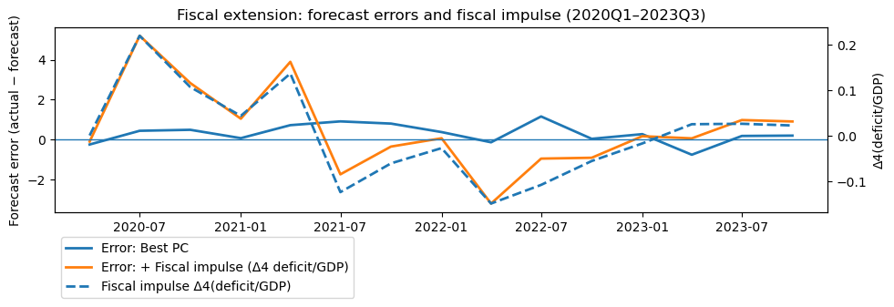

```python
# --- Exhibit 5: Fiscal extension (errors + fiscal impulse overlay), 2020Q1–2023Q3 ---

import numpy as np
import matplotlib.pyplot as plt

# REQUIREMENTS:
# - out_base: output from oos_eval() for baseline best PC spec
# - out_d4:   output from oos_eval() for baseline + fiscal_impulse_d4
# - df_test:  test dataframe (2020Q1–2023Q3) that contains period_q/date and fiscal_impulse_d4
#
# out_base["dtest"] and out_d4["dtest"] must contain: ["period_q","date","err"] at minimum.

# 1) Collect errors and merge to common index
e_base = out_base["dtest"][["period_q", "date", "err"]].copy().rename(columns={"err": "err_base"})
e_fisc = out_d4["dtest"][["period_q", "date", "err"]].copy().rename(columns={"err": "err_fisc"})

d = (
    e_base.merge(e_fisc, on=["period_q", "date"], how="inner")
          .merge(df_test[["period_q", "date", "fiscal_impulse_d4"]], on=["period_q", "date"], how="left")
          .sort_values("date")
)

# 2) Safety checks (helpful when debugging)
assert d["err_base"].notna().all(), "Missing baseline errors after merge."
assert d["err_fisc"].notna().all(), "Missing fiscal-augmented errors after merge."
assert d["fiscal_impulse_d4"].notna().all(), "Missing fiscal_impulse_d4 values in merged data."

# 3) Plot
fig, ax = plt.subplots(figsize=(10, 4))

ax.plot(d["date"], d["err_base"], label="Error: Best PC", linewidth=2)
ax.plot(d["date"], d["err_fisc"], label="Error: + Fiscal impulse (Δ4 deficit/GDP)", linewidth=2)

ax.axhline(0, linewidth=1)
ax.set_title("Fiscal extension: forecast errors and fiscal impulse (2020Q1–2023Q3)")
ax.set_ylabel("Forecast error (actual − forecast)")
ax.set_xlabel("")

# Secondary axis for fiscal impulse
ax2 = ax.twinx()
ax2.plot(d["date"], d["fiscal_impulse_d4"], linestyle="--", linewidth=2, label="Fiscal impulse Δ4(deficit/GDP)")
ax2.set_ylabel("Δ4(deficit/GDP)")

# Combined legend
lines1, labels1 = ax.get_legend_handles_labels()
lines2, labels2 = ax2.get_legend_handles_labels()
ax.legend(lines1 + lines2, labels1 + labels2, loc="lower left", bbox_to_anchor=(0, -0.5))

fig.tight_layout()
plt.show()

# 4) Optional: save
# fig.savefig("../results/figures/exhibit5_fiscal_errors_overlay.png", dpi=300, bbox_inches="tight")
```

```python
# --- Exhibit 5 (supporting text): coefficient output (train ≤2019Q4) ---
# Assumes your oos_eval() returns a statsmodels regression result object in out["res"].
# If your key is different, run: out_base.keys() and replace "res" accordingly.

import numpy as np

# Grab fitted (training) regression results
res_base = out_base["res"]   # baseline: exp + log_vu + energy
res_fisc = out_d4["res"]     # fiscal:   exp + log_vu + energy + fiscal_impulse_d4

def print_coefs(res, vars_list, title):
    print(title)
    for v in vars_list:
        b  = float(res.params[v])
        se = float(res.bse[v])
        t  = b / se if se != 0 else np.nan
        print(f"  {v:20s} {b:9.3f}  ({se:7.3f})   t={t:6.2f}")
    print()

vars_base = ["exp_mich_1y_mean", "log_vu", "pi_pce_energy_yoy"]
vars_fisc = vars_base + ["fiscal_impulse_d4"]

print_coefs(res_base, vars_base, "Baseline (train ≤2019Q4):")
print_coefs(res_fisc, vars_fisc, "+ Fiscal impulse Δ4(deficit/GDP) (train ≤2019Q4):")
```

```
Baseline (train ≤2019Q4):
  exp_mich_1y_mean         1.023  (  0.082)   t= 12.49
  log_vu                  -0.082  (  0.316)   t= -0.26
  pi_pce_energy_yoy        0.041  (  0.010)   t=  3.89

+ Fiscal impulse Δ4(deficit/GDP) (train ≤2019Q4):
  exp_mich_1y_mean         1.021  (  0.078)   t= 13.03
  log_vu                   0.159  (  0.256)   t=  0.62
  pi_pce_energy_yoy        0.043  (  0.011)   t=  3.81
  fiscal_impulse_d4       22.838  ( 11.845)   t=  1.93
```

```python
df_full.columns.tolist()
```

[output not shown]

[output cut: 15 more lines]

[output not shown]